# Hashing

Pencarian akan lebih cepat lagi jika semua data pada list terletak tepat berada ditempatnya masing-masing, sehingga pencarian dilakukan hanya dengan satu kali proses perbandingan saja.

Di dalam algoritma hashing ini terdapat beberapa istilah dasar sebagai berikut:

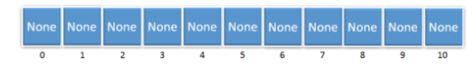

- Hash function yaitu suatu fungsi yang memetakan antara data dengan slot di dalam hash table

### Collison

Collision terjadi ketika dua data memiliki hasil hash yang sama sehingga masuk ke slot/index yang sama.

Contoh:

77 % 11 = 0 44 % 11 = 0

Penangan collusion ini dapat dilakukan dengan cara mencari kembali di dalam hash table slot yang kosong untuk data yang menyebabkan terjadinya collusion. Penanganan ini dikenal dengan konsep open addressing, yaitu pencarian slot kosong yang siap ditempati oleh data baru.

Contoh penanganan collusion sederhana berdasarkan konsep open adressing ini adalah Linear Probing, yaitu mencari slot kosong dengan cara mengunjungi slot-slot ini satu persatu, dimulai dari slot tempat terjadinya collusion.

Cara mengatasinya:

1. Chaining
2. Linear Probing

```python
def hash_function(key):
    return key % 10


# Data
data1 = 15
data2 = 25

# Hasil hash
index1 = hash_function(data1)
index2 = hash_function(data2)

print("Data", data1, "masuk ke index", index1)
print("Data", data2, "masuk ke index", index2)

# Cek collision
if index1 == index2:
    print("Terjadi collision!")
else:
    print("Tidak terjadi collision")
```

```
Data 15 masuk ke index 5
Data 25 masuk ke index 5
Terjadi collision!
```

```python
# Linear Probing
table = [None] * 11

def hash(x):
    return x % 11

def insert(table, key, value):

    index = hash(key)

    if table[index] == None:
        table[index] = value

    else:
        collision = index
        found = False

        ind = collision + 1

        if ind >= len(table)-1:
            ind = 0

        while (ind <= len(table)-1) and not(found):

            if table[ind] == None:
                found = True
                table[ind] = value

            ind = ind + 1


insert(table,54,54)
insert(table,26,26)
insert(table,93,93)
insert(table,17,17)
insert(table,77,77)
insert(table,31,31)
insert(table,44,44)
insert(table,55,55)
insert(table,20,20)

print(table)
```

```
[77, 44, 55, 20, 26, 93, 17, None, None, 31, 54]
```

```python
# Hash Table dengan Chaining

hash_table = [[] for _ in range(10)]


def hash_function(key):
    return key % 10


def insert(key):
    index = hash_function(key)
    hash_table[index].append(key)



data = [15, 25, 35, 7]

for item in data:
    insert(item)
for i in range(len(hash_table)):

    print("Index", i, ":", hash_table[i])
```

```
Index 0 : []
Index 1 : []
Index 2 : []
Index 3 : []
Index 4 : []
Index 5 : [15, 25, 35]
Index 6 : []
Index 7 : [7]
Index 8 : []
Index 9 : []
```

```python
table = [None] * 11

def hash(x):
    return x % 11

def insert(table, key, value):

    index = hash(key)

    if table[index] == None:
        table[index] = value

    else:

        collision = index
        found = False
        i = 1

        ind = collision + 1

        if ind > len(table)-1:
            ind = 0

        while (ind <= len(table)-1) and not(found):

            if table[ind] == None:
                found = True
                table[ind] = value

            ind = (collision + (i*i)) % 11
            i = i + 1


insert(table,54,54)
insert(table,26,26)
insert(table,93,93)
insert(table,17,17)
insert(table,77,77)
insert(table,31,31)
insert(table,44,44)
insert(table,55,55)
insert(table,20,20)

print(table)
```

```
[77, 44, 20, 55, 26, 93, 17, None, None, 31, 54]
```